# Portfolio Development with SP500 Securities Using Applied Financial Mathematics

#### Calculate and plot value the portfolio’s value trajectory

The APT market neutral value trajectory can be calculated using the weights and proportion from the previous chunk. Each portfolio position is multiplied by its respective weight to get the long and short trajectories. The total trajectory is then derived by multiplying the proportion by long minus short. I’ve visualized the line below alongside the portfolio returns.

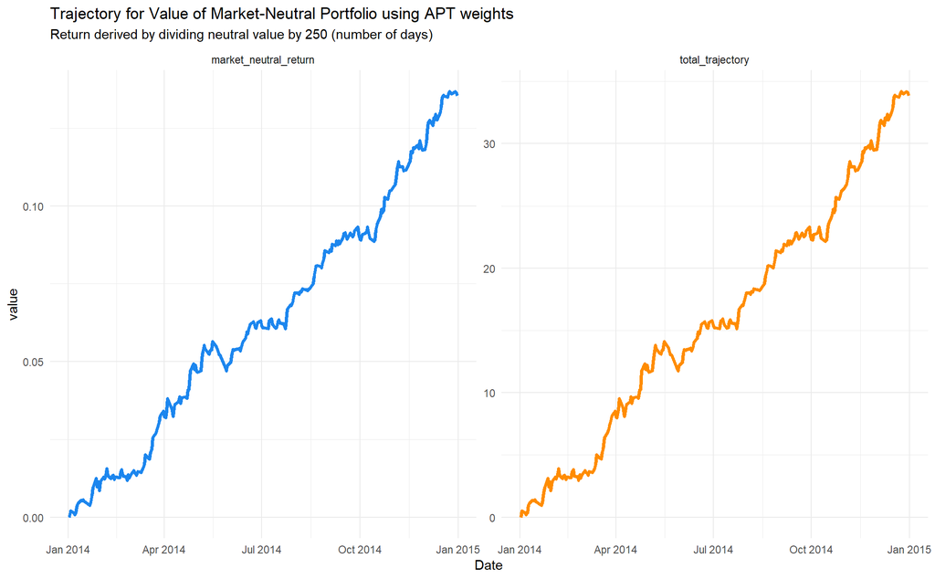

```r
apt_portfolio_trajectory <- data.frame(
  long_trajectory = as.matrix(sp500_2014[,-(1:3)])[,long_apt_weights$stock] %*%
    long_apt_weights$weight,
  short_trajectory = as.matrix(sp500_2014[,-(1:3)])[,short_apt_weights$stock] %*%
    short_apt_weights$weight
) %>%
  mutate(Date = sp500_2014$Date,
         total_trajectory = t(apt_weights$weight[5] %*%
           long_trajectory - short_trajectory) %>% as.numeric(),
         market_neutral_return = total_trajectory / 250) %>%
  select(Date, total_trajectory, market_neutral_return)

apt_portfolio_trajectory %>%
  gather(key = "series", value = "value", -Date) %>%
  ggplot(aes(Date, value, colour = series)) +
  geom_line(size = 1.3, show.legend = F) +
  scale_colour_manual(values = c("dodgerblue2", "darkorange")) +
  facet_wrap(facets = "series", scales = "free") +
  labs(title = "Trajectory for Value of Market-Neutral Portfolio using APT weights",
       subtitle = "Return derived by dividing neutral value by 250 (number of days)")
```

[output not shown]

## Part 3: Hedging Market-Neutral Portfolio

#### Explore the relationship between SPY and the APT total trajectory. How strong is correlation and what is the expecation for regression fit?

As a starting point, I’ve visualized the SPY and APT portfolio cumulative returns. Owing to different scales though, any association is masked.

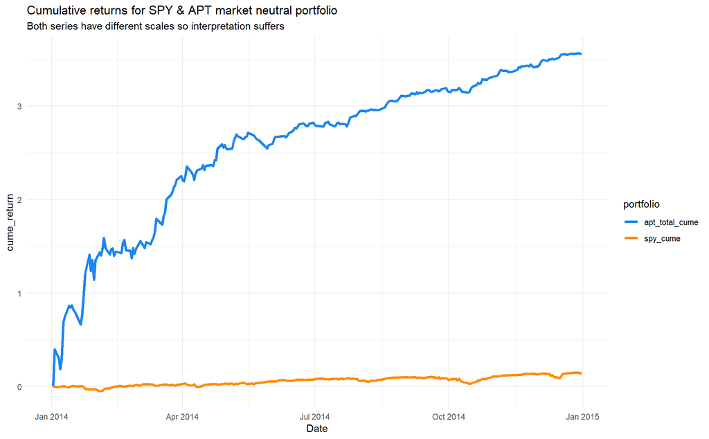

```r
apt_spy_cume <- data.frame(
  Date = sp500_2014$Date,
  spy_cume = mixed_portfolio$cume_return[mixed_portfolio$Security == "cume_spy_return"],
  apt_total_cume = cumsum(c(0, diff(log(1 + apt_portfolio_trajectory$total_trajectory))))
)

apt_spy_cume %>%
  gather(key = "portfolio", value = "cume_return", -Date) %>%
  ggplot(aes(Date, cume_return, colour = portfolio)) +
  geom_line(size = 1.3) +
  scale_colour_manual(values = c("dodgerblue2", "darkorange")) +
  labs(title = "Cumulative returns for SPY & APT market neutral portfolio",
       subtitle = "Both series have different scales so interpretation suffers")
```

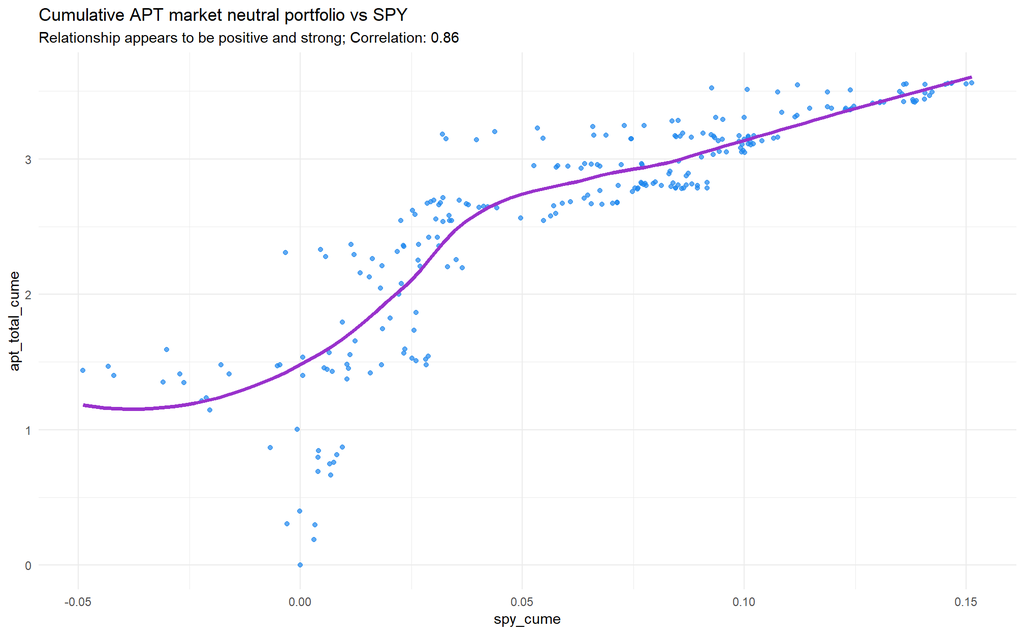

```r
apt_spy_cume %>%
  ggplot(aes(spy_cume, apt_total_cume)) +
  geom_point(alpha = .7, colour = "dodgerblue2") +
  geom_smooth(method = "loess", se = F, size = 1.3, colour = "darkorchid") +
  labs(title = "Cumulative APT market neutral portfolio vs SPY",
       subtitle = paste("Relationship appears to be positive and strong; Correlation:", cor(apt_spy_cume$spy_cume, apt_spy_cume$apt_total_cume) %>% round(2)))
```

### Hedging using regression

As expected, a linear model between the two variables shows a highly significant slope and overall model p-value. The slope values provides the hedging ratio between the two series and indicates that for 1 unit of the portfolio, the hedge contains approximately -32 units of SPY.

```r
hedge_ratio_lm <- lm(apt_total_cume ~ spy_cume- 1, data = apt_spy_cume)

summary(hedge_ratio_lm)
```

```
##
## Call:
## lm(formula = apt_total_cume ~ spy_cume - 1, data = apt_spy_cume)
##
## Residuals:
##     Min      1Q  Median      3Q     Max
## -1.3011 -0.0053  0.5579  1.3168  3.0130
##
## Coefficients:
##          Estimate Std. Error t value Pr(>|t|)
## spy_cume  32.1375     0.8911   36.07   <2e-16 ***
## ---
## Signif. codes:  0 '***' 0.001 '**' 0.01 '*' 0.05 '.' 0.1 ' ' 1
##
## Residual standard error: 1.087 on 249 degrees of freedom
## Multiple R-squared:  0.8393, Adjusted R-squared:  0.8387
## F-statistic:  1301 on 1 and 249 DF,  p-value: < 2.2e-16
```

#### What can you tell about the assumptions of the the model?

The model assumptions appear to be violated here. Given this is essentially a time series linear model, it isn’t surprising to see serial auto correlation and pattern in the residuals. However, this does violate the IID residual assumption. Additionally, the QQ-norm plot shows there are fat tails but, they seem to be close to normal. Overall, there are some assumption violations here.

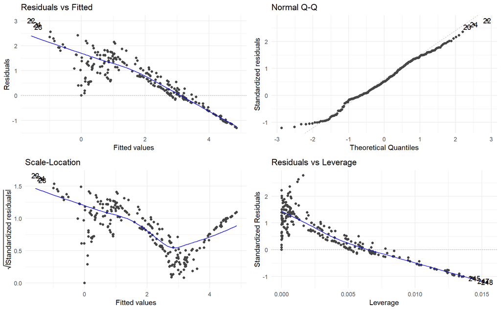

```r
autoplot(hedge_ratio_lm)
```

### Hedging using cointegration

Cointegration reviews if two time series move together but, vary along the way. The idea here is derived from a random walk where the two series are broadly going in the same direction, owing to some underlying structural connection, but aren’t necessarily taking the same path. Using the two portfolios here, the two classes are inherently part of the same market despite different compositions. With this, there’s an expectation that they should broadly be connected. This general intuition, coupled with the initial regression results indicating the series are closely related, suggest that doing cointegration modelling makes sense here.

Formally, two series are said to be cointegrated if each of the series taken individually is unit-root non-stationary, while there exists some linear combination of the series which is stationary for some non-zero vector. This cointegration can be tested using the Johansen Test, which is conducted using the `ca.jo` function. The test operates by forming vectorized auto-regressive models (a combination of two time series with a matrix that stores coefficients) which are then differenced to derive a Vector Error Correction Model. The test checks for the situation of no cointegration, which occurs when the coefficients matrix is 0. Assessing this is done using eigenvalue decomposition of this matrix. During this, the matrix rank is reviewed to sequentially test whether this rank is equal to zero or one. The null hypothesis is that the rank is zero, meaning there is no cointegration. Setting the test up, I’ve included both cumulative return series, specified the eigenvalue decomposition, selected two lag checks for the test, and specified long run to construct the Vector Error Correction Model reviewed above.

The initial summary provides some insight into the cointegration testing. The test values for $(r = 0)$, or no cointegration, shows the 10% and 5% levels as being significant. With this, the null hypothesis can be rejected. However, the second test, $(r \leq 1)$, shows a test statistic that is lower than all three confidence levels. In this case, the null cannot be rejected. Putting these both together, the cointegration order can be specified as 1, which means the rank of the coefficient matrix is one. Further, this means that a linear combination of both series should form a stationary series.

```r
apt_spy_cume <- apt_spy_cume %>%
  select(apt_total_cume, spy_cume, -Date)

portfolio_johansen <- ca.jo(x = apt_spy_cume,
                            ecdet = "none",
                            type = "eigen",
                            K = 2,
                            spec = "longrun")

summary(portfolio_johansen)
```

```
##
## ######################
## # Johansen-Procedure #
## ######################
##
## Test type: maximal eigenvalue statistic (lambda max) , with linear trend
##
## Eigenvalues (lambda):
## [1] 0.06456340 0.02474226
##
## Values of teststatistic and critical values of test:
##
##           test 10pct  5pct  1pct
## r <= 1 |  6.21  6.50  8.18 11.65
## r = 0  | 16.55 12.91 14.90 19.19
##
## Eigenvectors, normalised to first column:
## (These are the cointegration relations)
##
##                   apt_total_cume.l2 spy_cume.l2
## apt_total_cume.l2           1.00000     1.00000
## spy_cume.l2               -11.43419   -37.96959
##
## Weights W:
## (This is the loading matrix)
##
##                  apt_total_cume.l2  spy_cume.l2
## apt_total_cume.d       -0.03203772 0.0025720933
## spy_cume.d              0.00237988 0.0008223354
```

To highlight the test result, I’ve also visualized the result. It reaffirms the cointegration order is one.

```r
johansen_test_vals <- portfolio_johansen@cval %>%
  as.data.frame() %>%
  rownames_to_column(var = "coint_test") %>%
  mutate(test_stat = portfolio_johansen@teststat) %>%
  select(coint_test, test_stat, everything())

johansen_test_vals %>%
  custom_kable()
```

| coint_test | test_stat | 10pct | 5pct | 1pct |
| --- | --- | --- | --- | --- |
| r <= 1 \| | 6.213266 | 6.50 | 8.18 | 11.65 |
| r = 0 \| | 16.551992 | 12.91 | 14.90 | 19.19 |

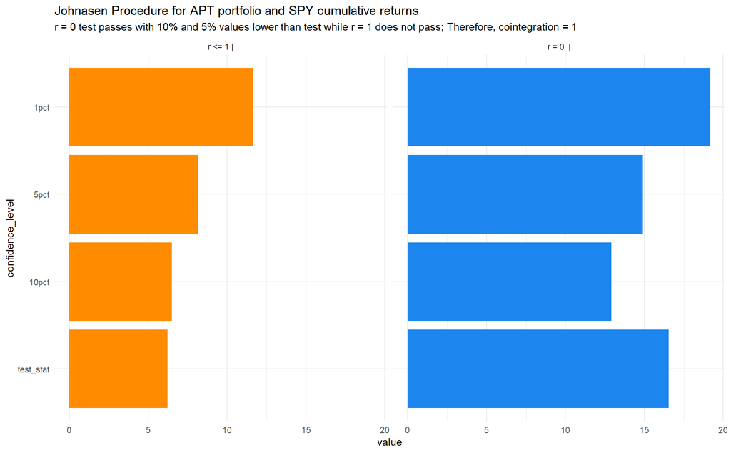

```r
johansen_test_vals %>%
  gather(key = "confidence_level", value = "value", -coint_test) %>%
  mutate(confidence_level = factor(confidence_level, levels = c("test_stat", "10pct",
                                                                "5pct", "1pct"))) %>%
  ggplot(aes(confidence_level, value, fill = coint_test)) +
  geom_col(show.legend = F) +
  scale_fill_manual(values = c("darkorange", "dodgerblue2")) +
  facet_wrap(facets = "coint_test") +
  coord_flip() +
  labs(title = "Johnasen Procedure for APT portfolio and SPY cumulative returns",
       subtitle = "r = 0 test passes with 10% and 5% values lower than test while r = 1 does not pass; Therefore, cointegration = 1")
```

The residuals show that the first series may have some auto-correlation, especially in the first 60 days of 2014. This may cause stationarity issues but, overall the series should have statistical equilibrium. However, the second cannot be stationary given it is not a cointegration vector.

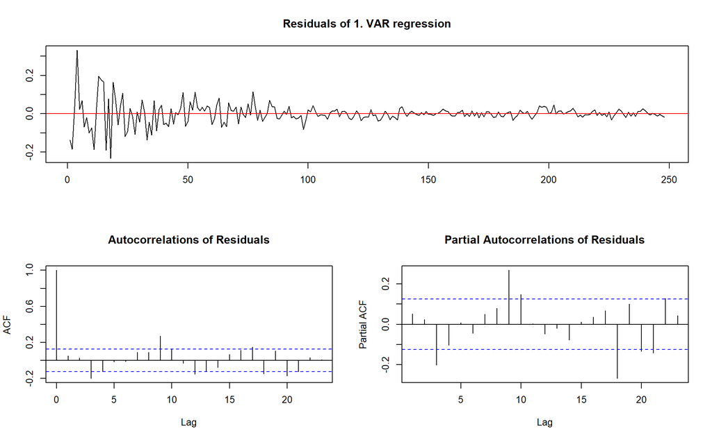

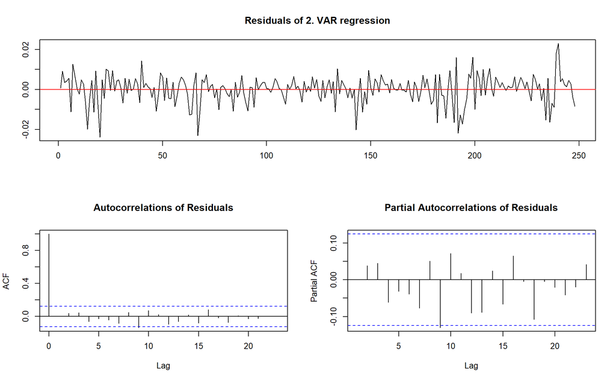

```r
plotres(portfolio_johansen)
```

The hedging ratio for each cointegration series is found using the V matrix, which is the eigen vector matrix normalized to the first column. As seen, the hedging ratio for the first cointegration vector is -11.434. Implicitly, this should be the cointegration vector given the test result but, I’ll review the stationarity for both.

```r
portfolio_johansen@V %>%
  custom_kable()
```

|  | apt_total_cume.l2 | spy_cume.l2 |
| --- | --- | --- |
| apt_total_cume.l2 | 1.00000 | 1.00000 |
| spy_cume.l2 | -11.43419 | -37.96959 |

From a visual perspective, both cointegration mixtures can be evaluated by reviewing if they have broad statistical equilibrium. These series are derived by multiplying SPY’s cumulative return with the normalized eigen vector values from above. These linear combinations form the model residuals for the cointegration. Zt1 appears to be stationary given the series below. That said, the first 60 days seem slightly more erratic.

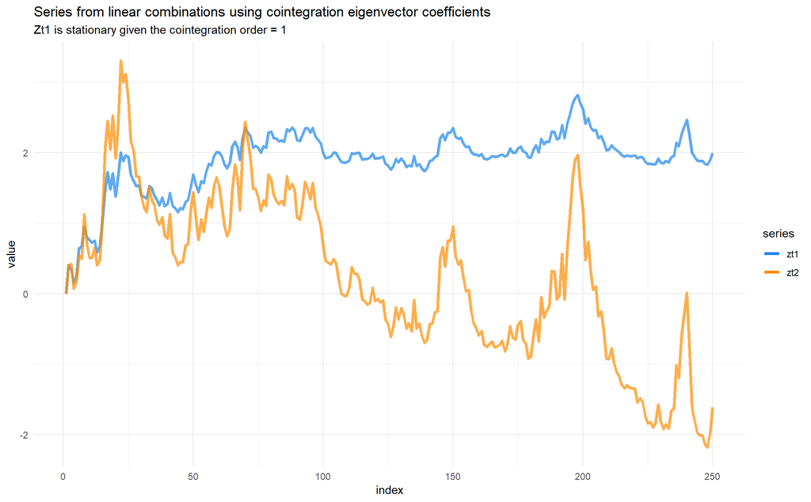

```r
coint_series <- data.frame(
  zt1 = as.matrix(apt_spy_cume) %*% portfolio_johansen@V[,1],
  zt2 = as.matrix(apt_spy_cume) %*% portfolio_johansen@V[,2]
) %>%
  mutate(index = row_number())

coint_series %>%
  gather(key = "series", value = "value", -index) %>%
  ggplot(aes(index, value, colour = series)) +
  geom_line(size = 1.3, alpha = .7) +
  scale_colour_manual(values = c("dodgerblue2", "darkorange")) +
  guides(colour = guide_legend(override.aes = list(alpha = 1))) +
  labs(title = "Series from linear combinations using cointegration eigenvector coefficients",
       subtitle = "Zt1 is stationary given the cointegration order = 1")
```

More formally, these can be tested by reviewing the roots for the characteristic equation. I’ve done this for the full Zt1 and a series with the first 60 days removed. Both circles are outside the unit circle indicating they are both stationary. The series with 60 days removed also shows a distance further from the circle indicating that process helped move it away from the non-stationary territory. The final series, Zt2, is also outside the unit circle showing it’s technically stationary. However, it’s less so than the initial cointegration mix making the first one preferable. Given this, the hedging ratio is from Zt1, which is 1, -11.434.

```r
zar_full <- ar(coint_series$zt1,  aic = TRUE ,method = "yule-walker")

zar_shortened <- ar(coint_series$zt1[-(1:60)],  aic = TRUE, method = "yule-walker")

zar2 <- ar(coint_series$zt2,  aic = TRUE ,method = "yule-walker")

par(mfrow = c(3, 2), cex = 0.9)
armaRoots(zar_full$ar,lwd = 8, n.plot = 400, digits = 8)
```

```
##         re im     dist
## 1 1.073825  0 1.073825
```

```r
armaRoots(zar_shortened$ar,lwd = 8, n.plot = 400, digits = 8)
```

```
##        re im    dist
## 1 1.09737  0 1.09737
```

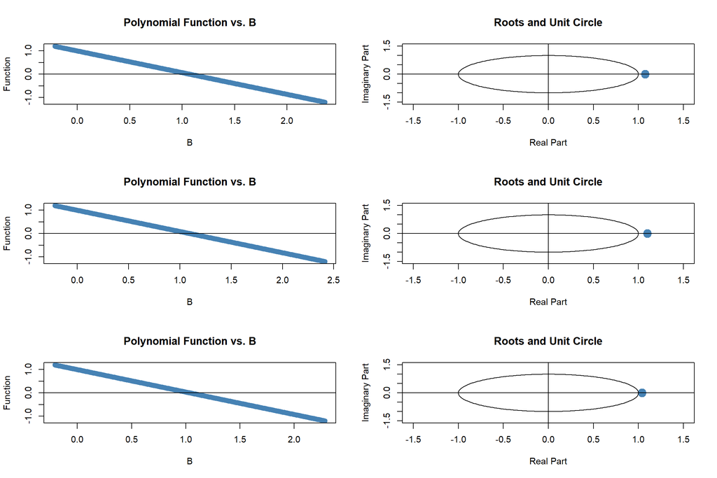

```
##         re im     dist
## 1 1.038259  0 1.038259
```

```r
armaRoots(zar2$ar,lwd = 8, n.plot = 400, digits = 8)
```

When reviewing residuals from both models, it’s clear that Zt1 has the most appropriate fit here. Interestingly, the regression model and Zt2 look quite similar.

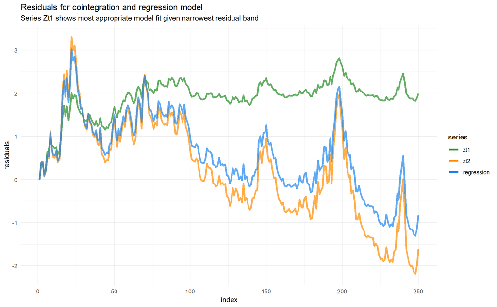

```r
coint_series <- coint_series %>%
  mutate(regression = hedge_ratio_lm$residuals)

coint_series %>%
  gather(key = "series", value = "residuals", -index) %>%
  mutate(series = factor(series, levels = c("zt1", "zt2", "regression"))) %>%
  ggplot(aes(index, residuals, colour = series)) +
  geom_line(size = 1.3, alpha = .7) +
  scale_y_continuous(breaks = seq(-4, 4, 1)) +
  scale_colour_manual(values = c("forestgreen", "darkorange", "dodgerblue2")) +
  guides(colour = guide_legend(override.aes = list(alpha = 1))) +
  labs(title = "Residuals for cointegration and regression model",
       subtitle = "Series Zt1 shows most appropriate model fit given narrowest residual band")
```

This is confirmed when looking at both hedging ratios

```r
data.frame(
  model = c("regression", "zt2"),
  hedge_ratio = c(hedge_ratio_lm$coefficients %>% as.numeric(),
                  portfolio_johansen@V[4] %>% abs())
) %>% custom_kable()
```

| model | hedge_ratio |
| --- | --- |
| regression | 32.13754 |
| zt2 | 37.96959 |

#### Compute summary statistics for series residuals. Zt1 is shifted relative to zero- Do you see this as a problem?

As a final step I’ve computed the summary statistics, which reaffirm the visual assessment of residuals. Here, Zt1 has the lowest residual standard deviation confirming it as the most appropriate fit.

```r
series_sd <- coint_series %>%
  select(-index) %>%
  map_dbl(.f = sd)

coint_series %>%
  select(-index) %>%
  apply(. , 2, summary) %>%
  rbind(sd = series_sd) %>%
  custom_kable()
```

|  | zt1 | zt2 | regression |
| --- | --- | --- | --- |
| Min. | 0.0000000 | -2.1834982 | -1.3011297 |
| 1st Qu. | 1.8219995 | -0.5711951 | -0.0053001 |
| Median | 1.9470901 | 0.2951765 | 0.5579104 |
| Mean | 1.8792782 | 0.2453928 | 0.6044943 |
| 3rd Qu. | 2.1349336 | 1.1680029 | 1.3168195 |
| Max. | 2.8148181 | 3.2988949 | 3.0130249 |
| sd | 0.4418753 | 1.1504867 | 0.9022414 |

The relative residual shift to zero isn’t worrying here. All this means is that the residuals have been transformed by subtracting the minimum from each value. This transformation doesn’t inherently affect the standard deviation given the average distance from the mean doesn’t change. I’ve highlighted this below by changing all the series residuals relative to zero. As seen, the standard deviation doesn’t change. With this, Zt1 one is still the preferable modelling choice.

```r
series_sd <- coint_series %>%
  select(-index) %>%
  mutate_all(function(x) x - min(x)) %>%
  map_dbl(.f = sd)

coint_series %>%
  select(-index) %>%
  mutate_all(function(x) x - min(x)) %>%
  apply(. , 2, summary) %>%
  rbind(sd = series_sd) %>%
  custom_kable()
```

|  | zt1 | zt2 | regression |
| --- | --- | --- | --- |
| Min. | 0.0000000 | 0.000000 | 0.0000000 |
| 1st Qu. | 1.8219995 | 1.612303 | 1.2958295 |
| Median | 1.9470901 | 2.478675 | 1.8590401 |
| Mean | 1.8792782 | 2.428891 | 1.9056239 |
| 3rd Qu. | 2.1349336 | 3.351501 | 2.6179492 |
| Max. | 2.8148181 | 5.482393 | 4.3141546 |
| sd | 0.4418753 | 1.150487 | 0.9022414 |